# Module 13. Advanced extensions

Slides

## Five situations beyond the core toolkit ADVANCED

- Ordered categories: **cumulative-logit mixed model** (CLEAR)
- Participants grouped in clinics: **three-level model** (WALK)
- A curve with meaningful parameters: **nonlinear mixed model** (WALK)
- A biomarker and an event: **joint model** (KIDNEY)
- Treatment that responds to the patient: **marginal structural model** (simulation)

**Simulated data**

All examples use simulated data from fictional studies. Results illustrate methods; they are not empirical findings.

# Ordinal repeated outcomes

## Itch severity is ordered, so keep the order ADVANCED

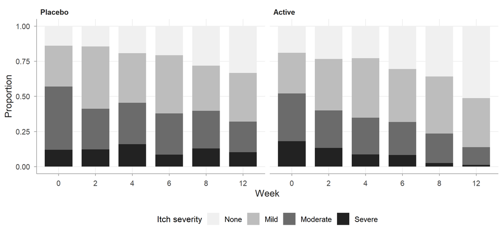

## One set of slopes moves every threshold ADVANCED

$$\operatorname{logit} P(Y_{ij} \le k \mid b_{0i}) = \theta_k - (\beta_1 t_{ij} + \beta_2 \text{Active}_i + \beta_3 t_{ij}\text{Active}_i + b_{0i})$$

- $\theta_0 < \theta_1 < \theta_2$: cut-points; no separate intercept
- Positive $\beta$: higher (worse) categories more likely (`ordinal` sign convention)
- $b_{0i} \sim N(0, \tau_0^2)$: participant’s persistent level
- **Proportional odds:** the same $\beta$ at every cut-point

## Fitting it with `clmm()` ADVANCED

```r
m_clmm <- clmm(severity_f ~ week * arm + (1 | id), data = clear, nAGQ = 7)
round(coef(summary(m_clmm)), 3)
```

```
#>                 Estimate Std. Error z value Pr(>|z|)
#> None|Mild         -2.676      0.261 -10.268    0.000
#> Mild|Moderate     -0.095      0.241  -0.394    0.694
#> Moderate|Severe    2.431      0.260   9.341    0.000
#> week              -0.096      0.023  -4.205    0.000
#> armActive         -0.098      0.335  -0.293    0.770
#> week:armActive    -0.122      0.033  -3.710    0.000
```

```r
sqrt(as.numeric(VarCorr(m_clmm)$id))     # random-intercept SD
```

```
#> [1] 1.882
```

## Active treatment cuts the odds of worse itch by week 12 ADVANCED

- Extra log-odds change per week, active vs placebo: **-0.122** (SE 0.033)
- Over 12 weeks: cumulative odds ratio **0.23** (95% CI 0.11 to 0.50)
- Same odds ratio for “mild or worse”, “moderate or worse”, “severe”
- Truth (simulated): extra slope -0.16, placebo slope -0.06, SD 2

## Report probabilities, conditional and marginal ADVANCED

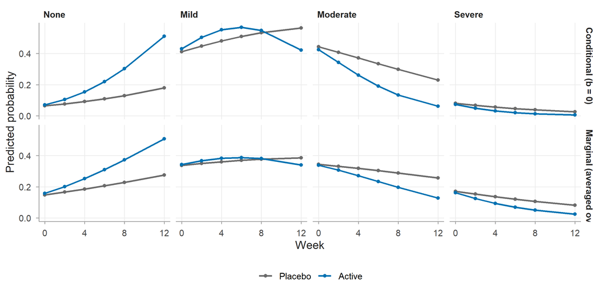

## Check proportional odds: let slopes vary by cut-point ADVANCED

```r
clear_df <- as.data.frame(clear) |> mutate(week_act = week * (arm == "Active"))
m_po  <- clmm2(severity_f ~ week + arm + week_act, random = id,
               data = clear_df, Hess = TRUE, nAGQ = 7)
m_npo <- clmm2(severity_f ~ arm, nominal = ~ week + week_act, random = id,
               data = clear_df, Hess = TRUE, nAGQ = 7)
po_lrt <- anova(m_po, m_npo)
```

LR statistic 5.21 on 4 df, p = 0.266: no evidence against proportional odds.

## Nominal outcomes need a multinomial model ADVANCED

$$\log \frac{P(Y_{ij} = k \mid \mathbf{b}_i)}{P(Y_{ij} = 0 \mid \mathbf{b}_i)} = \mathbf{x}_{ij}^\top \boldsymbol\beta_k + b_{ik}, \quad k = 1, \dots, K$$

- Each category has its own coefficients and (correlated) random intercept
- Options: full baseline-category logit GLMM (specialist software), separate binary GLMMs (approximate), multinomial GEE (marginal)
- **Specialist:** nominal outcome, failed proportional odds for treatment, random slopes, primary endpoint

## Try it ADVANCED

Workbook exercise 1: fit the adjusted cumulative-logit model, compare with the truth, and compute predicted probabilities at week 12.

# Three-level data

## WALK participants are nested in 8 clinics ADVANCED

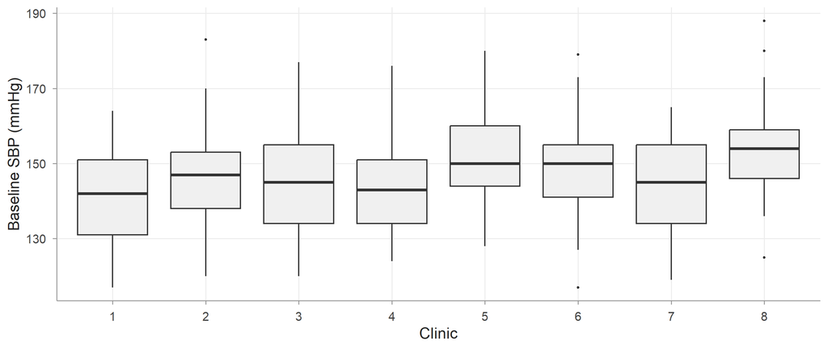

Visits (level 1) within participants (level 2) within clinics (level 3). Every clinic has all three arms.

## A third random intercept adds a third variance component ADVANCED

$$y_{ij} = \mathbf{x}_{ij}^\top \boldsymbol\beta + u_c + b_{0i} + b_{1i} t_{ij} + \varepsilon_{ij}, \quad u_c \sim N(0, \tau_c^2)$$

```r
m3_ri <- lmer(sbp ~ visit_f * arm + (1 | clinic) + (1 | id),
              data = walk, control = lmer_ctrl)
vc <- as.data.frame(VarCorr(m3_ri))
v <- vc$vcov[match(c("clinic", "id", "Residual"), vc$grp)]
round(rbind(variance = v, share = v / sum(v)), 3)
```

```
#>           [,1]    [,2]   [,3]
#> variance 9.586 135.980 37.834
#> share    0.052   0.741  0.206
```

## Eight clinics say little about clinic variation ADVANCED

- Clinic SD in the primary model: **3.1 mmHg**
- Profile 95% CI: **1.3 to 5.8 mmHg** (upper limit more than 4 times the lower)
- Truth (simulated): 3 mmHg; the 8 clinic effects actually drawn have SD 2.16

## Fixed, random or ignored: the contrast hardly changes here ADVANCED

| model | contrast | estimate | se | lower | upper |
| --- | --- | --- | --- | --- | --- |
| Two-level (clinic ignored) | change SP - change UC | -5.38 | 1.42 | -8.54 | -2.21 |
| Two-level (clinic ignored) | change EP - change UC | -8.97 | 1.44 | -12.17 | -5.77 |
| Three-level (clinic random) | change SP - change UC | -5.35 | 1.42 | -8.52 | -2.18 |
| Three-level (clinic random) | change EP - change UC | -8.94 | 1.44 | -12.14 | -5.74 |
| Clinic as fixed effect | change SP - change UC | -5.34 | 1.42 | -8.51 | -2.18 |
| Clinic as fixed effect | change EP - change UC | -8.93 | 1.44 | -12.13 | -5.73 |

## Try it ADVANCED

Workbook exercise 2: partition the variance, then compare clinic as fixed and as random for the month-12 contrast.

# Nonlinear mixed models

## Blood pressure falls, then levels off ADVANCED

$$y_{ij} = \phi_{0i} - \phi_{1i}\left(1 - e^{-t_{ij}/\kappa}\right) + \varepsilon_{ij}$$

- $\phi_{0i} = \beta_0 + b_{0i}$: participant’s baseline SBP
- $\phi_{1i} = \beta_{\text{arm}} + b_{1i}$: participant’s plateau fall
- $\kappa$ (`tau` in code): months to reach 63% of the plateau
- Truth (simulated): plateau 2, 6, 9 mmHg excluding the steps-mediated part; $\kappa = 2$ months

## `nlme()` needs a formula, a fixed list and starting values ADVANCED

```r
start_vals   # mean baseline; observed fall to month 12 by arm; tau = 2
```

```
#>  base    A1    A2    A3   tau
#> 147.0   1.8   7.6  11.0   2.0
```

```r
m_nl2 <- nlme(sbp ~ base - A * (1 - exp(-month / tau)),
              data   = as.data.frame(walk),
              fixed  = list(base ~ 1, A ~ arm - 1, tau ~ 1),
              random = list(id = pdDiag(base + A ~ 1)),
              start  = start_vals)
round(nlme::fixef(m_nl2), 2)
```

```
#>    base A.armUC A.armSP A.armEP     tau
#>  146.69    1.36    6.77   10.19    2.06
```

## The parameters answer the question directly ADVANCED

| Parameter | Estimate (95% CI) | Simulated truth (total) |
| --- | --- | --- |
| Plateau fall, UC | 1.4 (-0.1 to 2.8) | 2.1 |
| Plateau fall, SP | 6.8 (5.3 to 8.2) | 6.7 |
| Plateau fall, EP | 10.2 (8.7 to 11.7) | 10.2 |
| Time constant (months) | 2.06 (1.53 to 2.59) | 2 |

## Try it ADVANCED

Workbook exercise 3: fit the asymptotic model, refit from different starts, and compute the difference in plateau fall between EP and UC.

# Joint models

## Measurements stop when kidneys fail ADVANCED

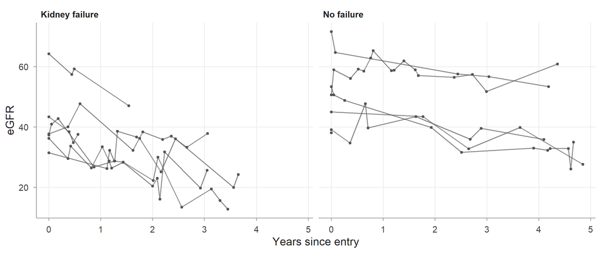

## Two submodels share the random effects ADVANCED

$$y_{ij} = m_i(t_{ij}) + \varepsilon_{ij}, \qquad m_i(t) = \mathbf{x}_i(t)^\top\boldsymbol\beta + \mathbf{z}_i(t)^\top\mathbf{b}_i$$
$$h_i(t) = h_0(t)\exp\{\gamma\,\text{Diabetes}_i + \alpha\, m_i(t)\}$$

- $m_i(t)$: true current eGFR, from the mixed model
- $\alpha$: log HR per unit of **current true** eGFR (truth: -0.13)

## `jm()` combines an `lme` and a `coxph` fit ADVANCED

```r
lme_egfr <- lme(egfr ~ ns(years, knots = 2.5, Boundary.knots = c(0, 5)) +
                  diabetes + diabetes:years + age10,
                random = ~ years | id, data = kid_long)
cox_fail <- coxph(Surv(time, failure) ~ diabetes, data = kid_ev)
jm_fit <- jm(cox_fail, lme_egfr, time_var = "years",
             functional_forms = ~ value(egfr),
             n_chains = 3L, n_iter = 25000L, n_burnin = 5000L, seed = 2026L)
```

## The joint model recovers the association; naive Cox attenuates it ADVANCED

| Model | $\hat\alpha$ (95% interval) | HR per 10 lower |
| --- | --- | --- |
| Joint model | -0.141 (-0.170 to -0.111) | 4.1 |
| Time-dependent Cox, last observed eGFR | -0.112 (-0.137 to -0.086) | 3.1 |
| Truth (simulated) | -0.13 | 3.7 |

MCMC: 3 chains, 25,000 iterations, 5,000 burn-in; Rhat 1.00 to 1.01.

## Try it ADVANCED

Workbook exercise 4: fit the submodels, load the saved joint model, read the association and compare with the naive Cox model.

# Time-varying confounding

## A confounder that is also affected by earlier treatment ADVANCED

```
flowchart LR
  L0["L0 baseline severity"] --> A0["A0 treatment, time 0"]
  L0 --> L1["L1 severity, time 1"]
  L0 --> Y["Y outcome"]
  A0 --> L1
  A0 --> A1["A1 treatment, time 1"]
  A0 --> Y
  L1 --> A1
  L1 --> Y
  A1 --> Y
  U["U unmeasured"] --> L1
  U --> Y
```

[output not shown]

## Weighting replaces adjustment ADVANCED

MSM: $E[Y^{a_0, a_1}] = \beta_0 + \beta_1 a_0 + \beta_2 a_1$ (truth: $\beta_1 = -3.2$, $\beta_2 = -2$)

$$SW_i = \prod_{t=0}^{1} \frac{P(A_t = a_{it} \mid \bar a_{i,t-1})}{P(A_t = a_{it} \mid \bar a_{i,t-1}, \bar l_{it})}$$

```r
ps1_den <- glm(A1 ~ A0 + L0 + L1, family = binomial, data = dat)
ps1_num <- glm(A1 ~ A0,           family = binomial, data = dat)
# ... same for A0; sw = product of num/den probabilities of treatment received
geeglm(Y ~ A0 + A1, data = dat, id = id, weights = sw, corstr = "independence")
```

## Standard adjustment fails; the MSM recovers both effects ADVANCED

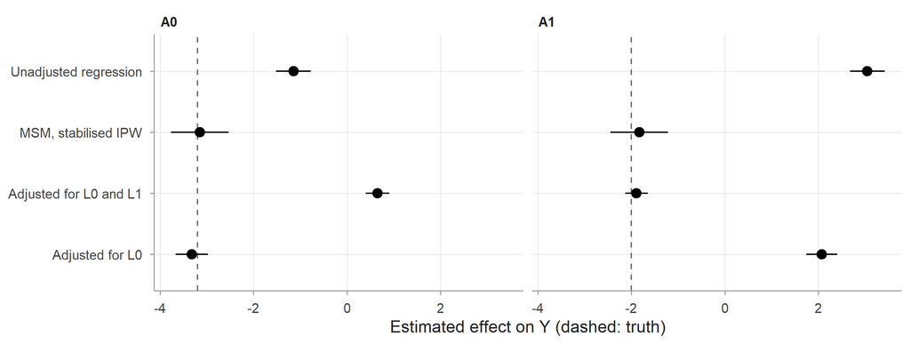

## Try it ADVANCED

Workbook exercise 5: compute stabilised weights by hand and fit the MSM; then change the data-generating mechanism.

# When to call a specialist

## Recognise the situation early, then bring in help ADVANCED

| Situation | Do it yourself | Involve a specialist |
| --- | --- | --- |
| Ordinal outcome | Random-intercept cumulative logit | Nominal outcome; PO fails for treatment |
| Clinics | Treatment within clinic | Cluster-randomised; few clusters |
| Curved trajectory | Simple curve, 1–2 random effects | PK/PD; fragile convergence |
| Biomarker and event | One biomarker, current value | Competing risks; prediction tools |
| Time-varying treatment | Draw the DAG | Always |